# Peer-graded Assignment: Prediction Assignment Writeup

### Background

Using devices such as Jawbone Up, Nike FuelBand, and Fitbit it is now possible to collect a large amount of data about personal activity relatively inexpensively. These type of devices are part of the quantified self movement - a group of enthusiasts who take measurements about themselves regularly to improve their health, to find patterns in their behavior, or because they are tech geeks. One thing that people regularly do is quantify how much of a particular activity they do, but they rarely quantify how well they do it. In this project, your goal will be to use data from accelerometers on the belt, forearm, arm, and dumbell of 6 participants. They were asked to perform barbell lifts correctly and incorrectly in 5 different ways. More information is available from the website here: http://web.archive.org/web/20161224072740/http:/groupware.les.inf.puc-rio.br/har (see the section on the Weight Lifting Exercise Dataset).

### Data

The training data for this project are available here:

https://d396qusza40orc.cloudfront.net/predmachlearn/pml-training.csv

The test data are available here:

https://d396qusza40orc.cloudfront.net/predmachlearn/pml-testing.csv

### Loading Library

This part load the library needed in this report.

```r
library(caret)
library(rpart)
library(rpart.plot)
library(randomForest)
```

### Data preprocessing

This part preprocess the data as explained in the comments.

```r
## Read files
train <- read.csv("pml-training.csv", na.strings=c("NA","#DIV/0!", ""))
test <- read.csv("pml-testing.csv", na.strings=c("NA","#DIV/0!", ""))

## Remove columns with NAs
train <- train[, colSums(is.na(train)) == 0]
test <- test[, colSums(is.na(test)) == 0]

## Remove irrelevant columns
train <- train[, -c(1:7)]
test <- test[, -c(1:7)]
```

### Cross-validation

We divide the data into train and test set with a ratio of 75:25.

```r
sub <- createDataPartition(y=train$classe, p=0.75, list=FALSE)
subTrain <- train[sub, ]
subTest <- train[-sub, ]
```

### Prediction 1: Decision Tree

We first try to fit data with simple decision tree and plot its structure.

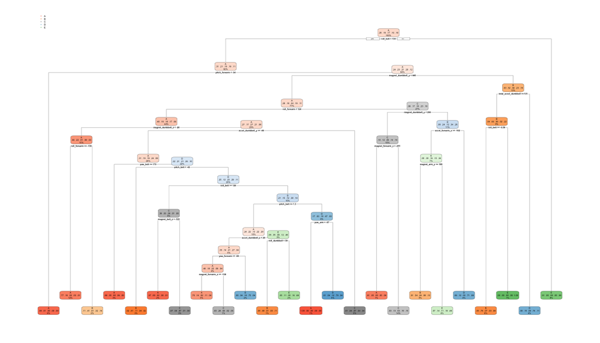

```r
model1 <- rpart(classe ~ ., data=subTrain, method="class")
rpart.plot(model1)
```

Then, we predict the data in the test set and analyze its accuracy.

```r
predict1 <- predict(model1, subTest, type = "class")
confusionMatrix(predict1, subTest$classe)
```

```
## Confusion Matrix and Statistics
##
##           Reference
## Prediction    A    B    C    D    E
##          A 1265  148   17   45   14
##          B   45  545   72   82   85
##          C   44  138  694  121  111
##          D   18   68   56  513   47
##          E   23   50   16   43  644
##
## Overall Statistics
##
##                Accuracy : 0.7465
##                  95% CI : (0.7341, 0.7587)
##     No Information Rate : 0.2845
##     P-Value [Acc > NIR] : < 2.2e-16
##
##                   Kappa : 0.6787
##  Mcnemar's Test P-Value : < 2.2e-16
##
## Statistics by Class:
##
##                      Class: A Class: B Class: C Class: D Class: E
## Sensitivity            0.9068   0.5743   0.8117   0.6381   0.7148
## Specificity            0.9362   0.9282   0.8978   0.9539   0.9670
## Pos Pred Value         0.8496   0.6574   0.6264   0.7308   0.8299
## Neg Pred Value         0.9619   0.9009   0.9576   0.9307   0.9377
## Prevalence             0.2845   0.1935   0.1743   0.1639   0.1837
## Detection Rate         0.2580   0.1111   0.1415   0.1046   0.1313
## Detection Prevalence   0.3036   0.1690   0.2259   0.1431   0.1582
## Balanced Accuracy      0.9215   0.7512   0.8547   0.7960   0.8409
```

### Prediction 2: Random Forest

In this section, we try a more compliated model which is the random forest.

```r
model2 <- randomForest(classe ~ ., data=subTrain, method = "class")
```

```r
predict2 <- predict(model2, subTest, type = "class")
confusionMatrix(predict2, subTest$classe)
```

```
## Confusion Matrix and Statistics
##
##           Reference
## Prediction    A    B    C    D    E
##          A 1394    3    0    0    0
##          B    0  945   14    0    0
##          C    0    1  841    6    0
##          D    0    0    0  798    2
##          E    1    0    0    0  899
##
## Overall Statistics
##
##                Accuracy : 0.9945
##                  95% CI : (0.992, 0.9964)
##     No Information Rate : 0.2845
##     P-Value [Acc > NIR] : < 2.2e-16
##
##                   Kappa : 0.993
##  Mcnemar's Test P-Value : NA
##
## Statistics by Class:
##
##                      Class: A Class: B Class: C Class: D Class: E
## Sensitivity            0.9993   0.9958   0.9836   0.9925   0.9978
## Specificity            0.9991   0.9965   0.9983   0.9995   0.9998
## Pos Pred Value         0.9979   0.9854   0.9917   0.9975   0.9989
## Neg Pred Value         0.9997   0.9990   0.9965   0.9985   0.9995
## Prevalence             0.2845   0.1935   0.1743   0.1639   0.1837
## Detection Rate         0.2843   0.1927   0.1715   0.1627   0.1833
## Detection Prevalence   0.2849   0.1956   0.1729   0.1631   0.1835
## Balanced Accuracy      0.9992   0.9961   0.9909   0.9960   0.9988
```

### Quiz

This section generate the answer for the quiz portion.

```r
predict(model2, test, type="class")
```

```
##  1  2  3  4  5  6  7  8  9 10 11 12 13 14 15 16 17 18 19 20
##  B  A  B  A  A  E  D  B  A  A  B  C  B  A  E  E  A  B  B  B
## Levels: A B C D E
```